# Reproducible Research: Peer Assessment 1

## Loading and preprocessing the data

Read in the data file from folder directory. Let’s take a look at the structure/stats and first few rows of the data set.

```r
activity <- read.csv('activity.csv')

head(activity);str(activity);summary(activity)
```

```
##   steps       date interval
## 1    NA 2012-10-01        0
## 2    NA 2012-10-01        5
## 3    NA 2012-10-01       10
## 4    NA 2012-10-01       15
## 5    NA 2012-10-01       20
## 6    NA 2012-10-01       25
```

```
## 'data.frame':    17568 obs. of  3 variables:
##  $ steps   : int  NA NA NA NA NA NA NA NA NA NA ...
##  $ date    : chr  "2012-10-01" "2012-10-01" "2012-10-01" "2012-10-01" ...
##  $ interval: int  0 5 10 15 20 25 30 35 40 45 ...
```

```
##      steps            date              interval
##  Min.   :  0.00   Length:17568       Min.   :   0.0
##  1st Qu.:  0.00   Class :character   1st Qu.: 588.8
##  Median :  0.00   Mode  :character   Median :1177.5
##  Mean   : 37.38                      Mean   :1177.5
##  3rd Qu.: 12.00                      3rd Qu.:1766.2
##  Max.   :806.00                      Max.   :2355.0
##  NA's   :2304
```

```r
activity$date <- as.Date(activity$date) #transform date column as date format
```

Load libraries needed:

```r
library(tidyverse)
```

## What is mean total number of steps taken per day?

### 1. Calculate the total number of steps taken per day

```r
act_total <- activity %>%
  group_by(date) %>%
  summarise(total_steps = sum(steps, na.rm = TRUE)) %>%
  select(date, total_steps)

act_total
```

```
## # A tibble: 61 × 2
##    date       total_steps
##    <date>           <int>
##  1 2012-10-01           0
##  2 2012-10-02         126
##  3 2012-10-03       11352
##  4 2012-10-04       12116
##  5 2012-10-05       13294
##  6 2012-10-06       15420
##  7 2012-10-07       11015
##  8 2012-10-08           0
##  9 2012-10-09       12811
## 10 2012-10-10        9900
## # ℹ 51 more rows
```

### 2. Make a histogram of the total number of steps taken each day

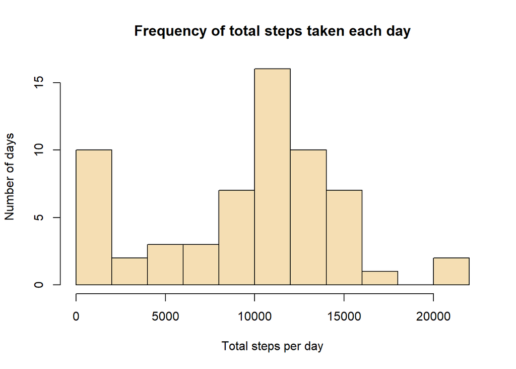

```r
hist(act_total$total_steps, col = "wheat", breaks = 10
     , main = "Frequency of total steps taken each day"
     , xlab = "Total steps per day"
     , ylab = "Number of days")
```

### 3. Calculate and report the mean and median of the total number of steps taken per day

```r
act_mean <- activity %>%
  filter(!is.na(steps) & steps !=0) %>%
  mutate(date = as.Date(date)) %>%
  group_by(date) %>%
  summarise(avg_steps = mean(steps, na.rm = TRUE),
            med_steps = median(steps, na.rm = TRUE)) %>%
  select(date, avg_steps, med_steps)

act_mean
```

```
## # A tibble: 53 × 3
##    date       avg_steps med_steps
##    <date>         <dbl>     <dbl>
##  1 2012-10-02      63        63
##  2 2012-10-03     140.       61
##  3 2012-10-04     121.       56.5
##  4 2012-10-05     155.       66
##  5 2012-10-06     145.       67
##  6 2012-10-07     102.       52.5
##  7 2012-10-09     135.       48
##  8 2012-10-10      95.2      56.5
##  9 2012-10-11     137.       35
## 10 2012-10-12     157.       46
## # ℹ 43 more rows
```

## What is the average daily activity pattern?

### 1. Make a time series plot (i.e. type = “l”) of the 5-minute interval (x-axis) and the average number of steps taken, averaged across all days (y-axis)

```r
act_mean_int <- activity %>%
  filter(!is.na(steps) & steps !=0) %>%
  mutate(DOW = wday(date, label = TRUE)) %>%
  group_by(DOW,interval) %>%
  summarise(avg_steps = mean(steps, na.rm = TRUE)) %>%
  select(DOW, interval, avg_steps)
```

[output not shown]

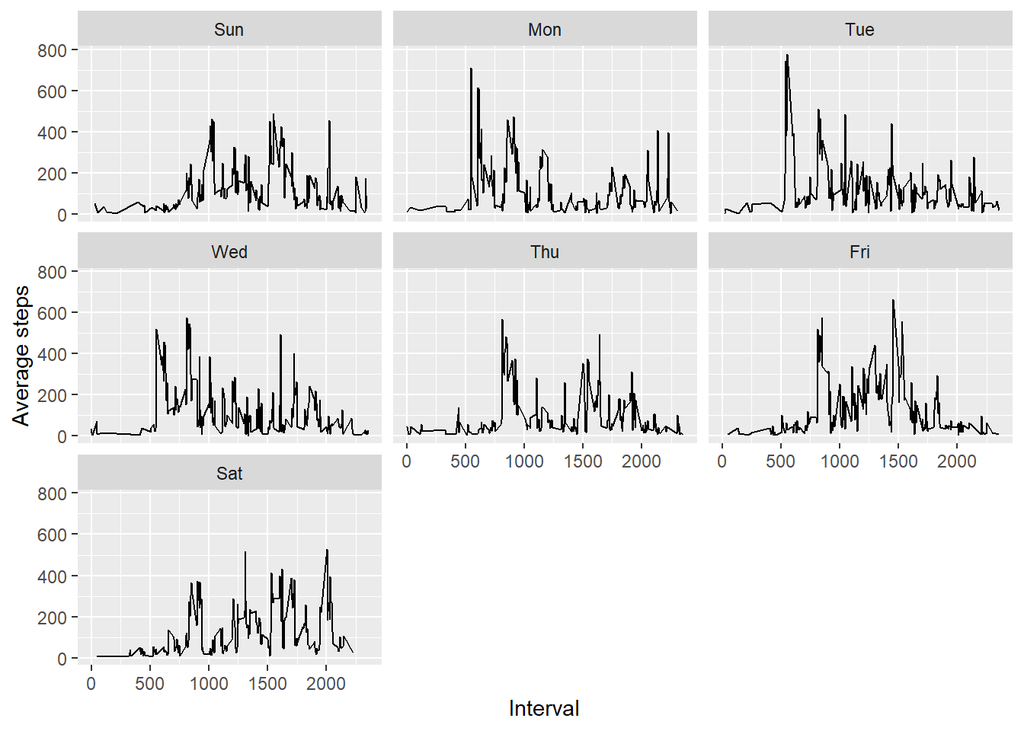

```r
ggplot(data = act_mean_int, aes(interval, avg_steps))+
  geom_line()+
  facet_wrap(vars(DOW))+
  labs(main = "Average steps by day and interval"
       , y = "Average steps"
       , x = "Interval")
```

### 2. Which 5-minute interval, on average across all the days in the dataset, contains the maximum number of steps?

```r
act_mean_int %>%
  group_by(interval) %>%
  summarise(max_steps = max(avg_steps, na.rm = TRUE)) %>%
  arrange(desc(max_steps)) %>%
  top_n(1)
```

```
## # A tibble: 1 × 2
##   interval max_steps
##      <int>     <dbl>
## 1      555       777
```

## Imputing missing values

### 1. Calculate and report the total number of missing values in the dataset (i.e. the total number of rows with NAs)

```r
activity_missingN <- activity %>% filter(is.na(steps)) %>% count()

activity_missingN
```

```
##      n
## 1 2304
```

### 2. Devise a strategy for filling in all of the missing values in the dataset.

```r
activity_replace <- activity %>% #create calculation of average steps per interval to use as fill in for NAs
  group_by(interval) %>%
  summarise(avg_steps = mean(steps, na.rm = TRUE))

activity2 <- activity %>% filter(is.na(steps)) #subset data of those that are NAs

activity2 <- cbind(activity2,activity_replace)[,c(5,2,3)] %>% rename(steps = avg_steps) #insert avg steps for those intervals with NAs

head(activity2) #shows that NAs have been replaced
```

```
##       steps       date interval
## 1 1.7169811 2012-10-01        0
## 2 0.3396226 2012-10-01        5
## 3 0.1320755 2012-10-01       10
## 4 0.1509434 2012-10-01       15
## 5 0.0754717 2012-10-01       20
## 6 2.0943396 2012-10-01       25
```

### 3. Create a new dataset that is equal to the original dataset but with the missing data filled in.

```r
activity1 <- activity %>% #create subset of dataset that doesn't have NAs
  filter(!is.na(steps))

activity_comb <- rbind(activity1,activity2) #combine the df where we filled in the NA steps back into the original df
```

### 4. Make a histogram of the total number of steps taken each day and Calculate and report the mean and median total number of steps taken per day. Do these values differ from the estimates from the first part of the assignment? What is the impact of imputing missing data on the estimates of the total daily number of steps?

Filling in NAs with the average steps for that missing interval does seem to smooth out the distribution in this revised histogram view versus the first histogram that was not including NAs.

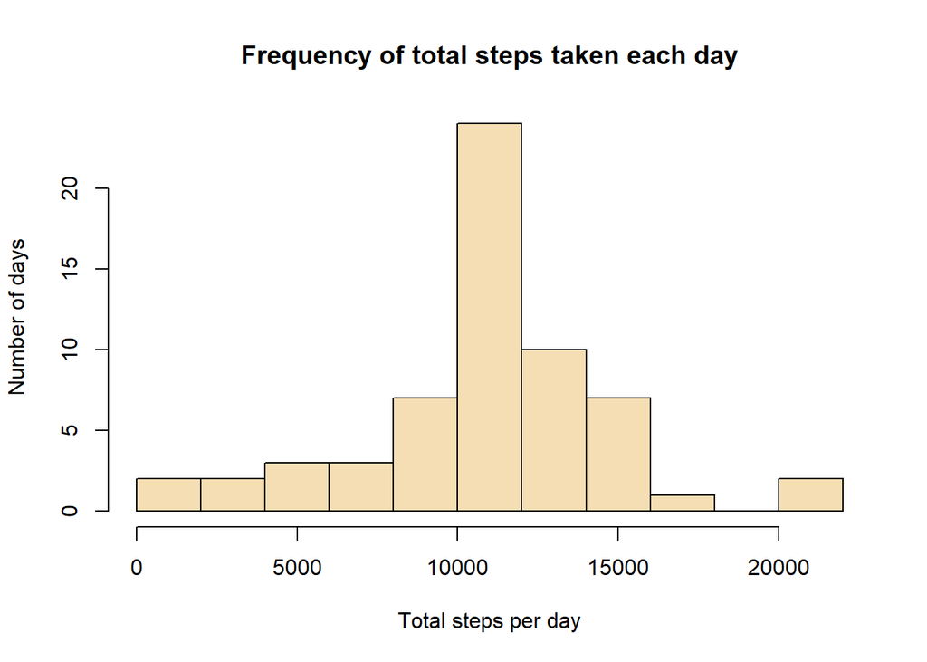

```r
act_comb_total <- activity_comb %>%
  group_by(date) %>%
  summarise(total_steps = sum(steps, na.rm = TRUE)) %>%
  select(date, total_steps)

hist(act_comb_total$total_steps, col = "wheat", breaks = 10
     , main = "Frequency of total steps taken each day"
     , xlab = "Total steps per day"
     , ylab = "Number of days")
```

```r
act_comb_mean <- activity_comb %>%
  filter(!is.na(steps) & steps !=0) %>%
  group_by(date) %>%
  summarise(avg_steps = mean(steps, na.rm = TRUE),
            med_steps = median(steps, na.rm = TRUE)) %>%
  select(date, avg_steps, med_steps)

head(act_mean);head(act_comb_mean)
```

```
## # A tibble: 6 × 3
##   date       avg_steps med_steps
##   <date>         <dbl>     <dbl>
## 1 2012-10-02       63       63
## 2 2012-10-03      140.      61
## 3 2012-10-04      121.      56.5
## 4 2012-10-05      155.      66
## 5 2012-10-06      145.      67
## 6 2012-10-07      102.      52.5
```

```
## # A tibble: 6 × 3
##   date       avg_steps med_steps
##   <date>         <dbl>     <dbl>
## 1 2012-10-01      40.0      37.5
## 2 2012-10-02      63        63
## 3 2012-10-03     140.       61
## 4 2012-10-04     121.       56.5
## 5 2012-10-05     155.       66
## 6 2012-10-06     145.       67
```

## Are there differences in activity patterns between weekdays and weekends?

### 1. Create a new factor variable in the dataset with two levels – “weekday” and “weekend” indicating whether a given date is a weekday or weekend day.

```r
activity_comb$DOW <- weekdays(activity_comb$date, abbreviate = TRUE)

act_wk <- activity_comb %>%
  mutate(day_type = as.factor(case_when(DOW %in% c("Sun","Sat") ~"weekend"
                              ,.default = "weekday"))) %>%
  group_by(day_type,interval) %>%
  summarise(avg_steps = mean(steps, na.rm = TRUE)) %>%
  select(day_type, interval,avg_steps)
```

### 2. Make a panel plot containing a time series plot (i.e. type = “l”) of the 5-minute interval (x-axis) and the average number of steps taken, averaged across all weekday days or weekend days (y-axis). See the README file in the GitHub repository to see an example of what this plot should look like using simulated data.

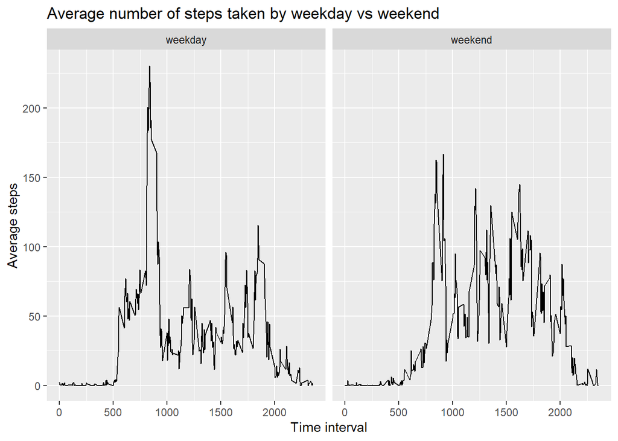

```r
ggplot(data = act_wk, aes(interval, avg_steps))+
  geom_line()+
  facet_wrap(vars(day_type))+
  labs(title = "Average number of steps taken by weekday vs weekend"
       , y = "Average steps"
       , x = "Time interval")
```